# Computation in GLMs

# 1 Introduction

The goals here are to computationally motivate interest in the likelihood terms of GLMs.

# 2 Motivating a regression

The data we will be looking at is turnout data in the 2016 election. It’s all over here somewhere (https://cces.gov.harvard.edu/data). In the spirit of open science, this is a heavily processed dataframe presented as if it was prepared in some sensible way without the information to support that.

First of all, let’s load up the data and have a look at it.

```r
df = read_delim("turnout_binomial.delim", " ")
print(df)
```

```
## # A tibble: 7,851 x 8
##    turned_out     M  male state        race  educ          age   marstat
##         <dbl> <dbl> <dbl> <chr>        <chr> <chr>         <chr> <chr>
##  1        133   170  -0.5 florida      white some_or_assoc 45-64 married
##  2        116   156  -0.5 pennsylvania white HS            45-64 married
##  3         98   132   0.5 california   white some_or_assoc 45-64 married
##  4         95   130   0.5 florida      white some_or_assoc 45-64 married
##  5         91   122  -0.5 ohio         white HS            45-64 married
##  6         76   122   0.5 california   white bach          45-64 married
##  7         87   120  -0.5 california   white some_or_assoc 45-64 married
##  8         79   117   0.5 texas        white some_or_assoc 45-64 married
##  9         77   115  -0.5 florida      white HS            45-64 married
## 10         84   114  -0.5 pennsylvania white some_or_assoc 45-64 married
## # … with 7,841 more rows
```

Each row in this dataset is information about how many people in different demographic groups turned out for the 2016 election. The leftmost variable `turned_out` is the actual response variable, so on the first line 133 out of 170 surveyed female, Floridian, white voters aged 45-64, etc. etc. turned out to vote.

What we do with data like this is estimate in each of these groups what the reported turnout in the survey group was, look at census data to figure out how many people are in these groups actually exist, and then estimate what the 2016 turnout (and do all sorts of follow up analysis with this).

Because we’re dealing with binary outcomes of a number of assumed homogenous people in different groups, we use the binomial as our likelihood. So we have `M` respondents and `turned_out` people actually reported they turned out – what is the probability than any individual person would have turned out?

The simple thing is to just look at `turned_out / M`, but that only works when `M` is large, and for many of our groups we have only a small number of people and such estimates will inevitably be too noisy to use, and so we will need to do better modeling (and here is the need for Stan).

# 3 Basic regression: `y ~ x`

The first thing we might do is simplify our problem. Can we just estimate the probability of survey respondents reporting they have turned out to vote simply by knowing if they are male or female?

In regression syntax, this looks like:

```
turned_out ~ male
```

It would be specified somewhere else that this is a binomial and that the total number of people in each group are `M`.

Before we do this regression we need to go ahead and compress the dataframe a bit. No need to worry about any of the covariates other than `male`.

```r
df_simple = df %>%
  group_by(male) %>%
  summarize(turned_out = sum(turned_out),
            M = sum(M))
print(df_simple)
```

```
## # A tibble: 2 x 3
##    male turned_out     M
##   <dbl>      <dbl> <dbl>
## 1  -0.5      15697 24662
## 2   0.5      12748 20548
```

This translates to the Stan code in models/simple.stan

```r
model = cmdstan_model("models/simple.stan")
fit = model$sample(data = list(N = nrow(df_simple),
                               M = df_simple$M,
                               turned_out = df_simple$turned_out,
                               male = df_simple$male),
                   cores = 4)
```

```r
print(fit)
```

```
##   variable      mean    median   sd  mad        q5       q95 rhat ess_bulk
##  lp__      -29806.00 -29805.70 1.02 0.74 -29808.10 -29805.00 1.00     2044
##  intercept      0.53      0.53 0.01 0.01      0.51      0.54 1.00     3342
##  slope         -0.07     -0.07 0.02 0.02     -0.10     -0.04 1.00     3421
##  ess_tail
##        NA
##      2568
##      2626
```

Alright, great, that model fit. Now before we move on, let’s discuss the computational aspects of this model.

## 3.1 Computation

The big work is all done in the model block:

```
turned_out ~ binomial_logit(M, intercept + slope * male);
```

## 3.2 Implicit parameters

There is an `intercept` and `slope` weren’t part of the regression version of the problem.

Traditionaly R regression syntax does not define the parameters. They are implicitly defined by what covariates are included on the right hand side.

`male` is a covariate, and so it gets a coefficient. If the intercept is not specified, it is assumed to be there.

`turned_out ~ 1 + male` is a verbose way to say include the intercept.

`turned_out ~ -1 + male` is a way of saying do not include the intercept.

## 3.3 Vectorization

This is a vectorized statement. It is equivalent to:

```
for(n in 1:N) {
  turned_out[n] ~ binomial_logit(M[n], intercept + slope * male[n]);
}
```

## 3.4 The model block is a function from $R^P \rightarrow R$

The model block in Stan represents a function which returns a single scalar, the log density of the model. You don’t see the log density increments because they are hidden behind `~` syntactic sugar. The log density is actually called `target` in Stan, and the previous loop is equivalent up to a constant of proportionality to:

```
for(n in 1:N) {
  target += binomial_logit_lpmf(turned_out[n] | M[n], intercept + slope * male[n]);
}
```

“up to a constant of proportionality” means that for the sake of sampling, they are the same, but in Stan the `~` operation actually drops some unnecessary calculations.

A Stan model is a Bayesian log density. This means it is a function mapping `P` parameters to a scalar output (the log density). This is why we do reverse mode autodiff – it is most efficient when there is only one output but many inputs.

## 3.5 Link functions

The distribution in the code is `binomial_logit`, not `binomial`. This is because the linear part of the model, `intercept + slope * male`, is unconstrained. `male` is either -0.5 (female) or 0.5 (male), but `slope` and `intercept can be anything, and so can the total. To map this unconstrained value to a constrained value, we use the inverse logit function.

For convenience, here is a reminder plot of inverse logit:

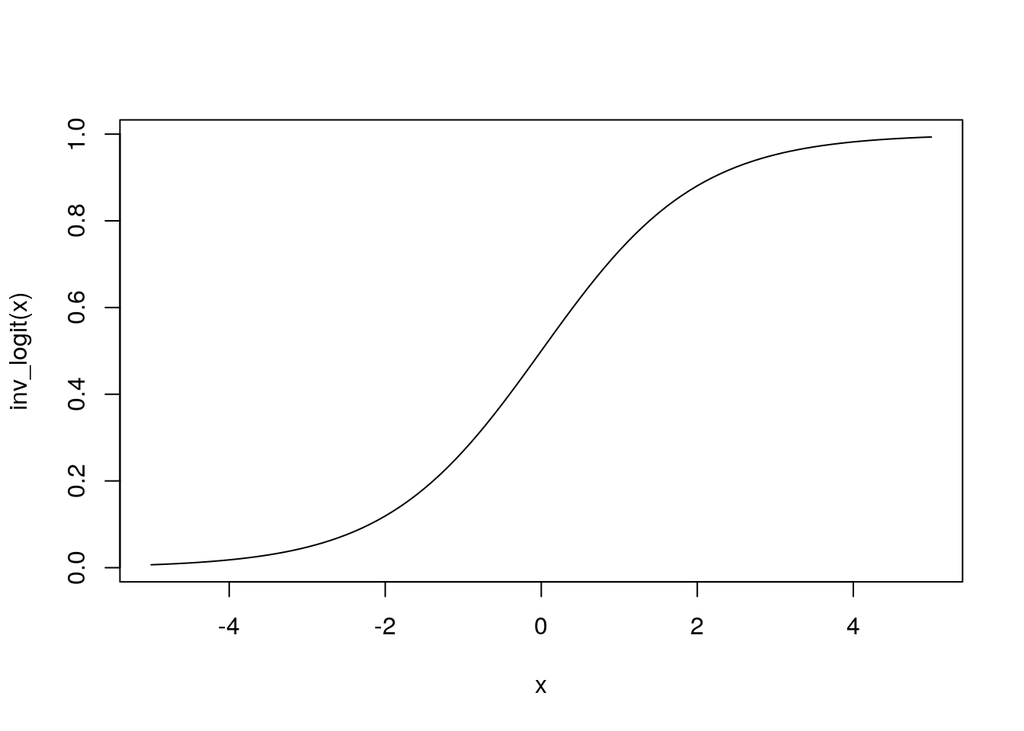

```r
inv_logit = function(x) { 1 / (1 + exp(-x)) }
curve(inv_logit, -5, 5)
```

`binomial_logit(N, x)` is the same as `binomial(N, inv_logit(x))`, but the numerics are more stable for the first so we use that.

We use `inv_logit` for convenience. Something else, or a low precision approximation, would probably be fine.

## 3.6 Data is static

The largest pieces of data do not change from model evaluation to model evaluation. What changes are the parameters.

This means the length `N` array of integers `M` does not change, the length `N` array of responses do not change, and the length `N` covariate `male` does not change. This means these things can be communicated once to every device involved in the computation and never need sent again.

If we look at the likelihood calculation as a whole, even though it is the majority of the work, only two doubles (`intercept` and `slope`) need shipped to the accerator during the forward pass and one double (`target`) returned. On the backwards pass, two doubles (the adjoints of `intercept` and `slope`) need shipped back from the accelerator.

# 4 Common modifications

There are a few modifications to make to this model.

## 4.1 Matrix-vector multiply formulation

We can add more covariates like `male`, and for each one there will be an additional parameter. Pretend we have another vector `income` which is a continuous variable representing the average income of a group. There would be an additional parameter `slope2` to go along with this. Something like:

```
turned_out ~ binomial_logit(M, intercept + slope1 * male + slope2 * income);
```

We can join the two vectors `male` and `income` into a single matrix `X`, and then combine `slope1` and `slope2` into a single vector `beta`, and the regression now looks like:

```
turned_out ~ binomial_logit(M, intercept + X * beta);
```

where `X` is an `N` by `K` design matrix of covariates and `beta` is a length `K` vector of parameters. Usually the non-hierarchical/population level terms are though of computationally as a matrix-vector multiply for this reason.

## 4.2 Other likelihoods

We can change the likelihood to something else. There are a lot of options.

We might have a normal:

```
y ~ normal(intercept + X * beta, sigma);
```

We might have a negative binomial:

```
y ~ neg_binomial_2_log(intercept + X * beta, phi);
```

There are many more families supported in `brms`, which is probably a good reference on the things we should be concerned about implementing: https://cran.r-project.org/web/packages/brms/vignettes/brms_families.html

## 4.4 Regressions on multiple parameters

We can have multiple linear models in one likelihood. For instance, we might predict both the mean and standard deviation of a normal distribution:

```
y ~ normal(intercept0 + X0 * beta0, exp(intercept1 + X1 * beta1));
```

Computationally, everything up until now is:

1. Linear model, expressed as a dense matrix vector multiply
2. Link function
3. Likelihood

# 5 Hierarchical term 1: `(1 | group)`

The term `(1 | group)` means add to the model an intercept that varies by what group the response belongs to. So we can expand the regression above to say that we expect the turnout to be different in every state:

```
turned_out ~ male + (1 | state)
```

This corresponds to the Stan model in models/groups.stan.

Similarly to before, we have to do a little work to prepare the regression.

```r
df_groups = df %>%
  mutate(state_idx = df$state %>% as.factor %>% as.numeric) %>%
  group_by(male, state_idx) %>%
  summarize(turned_out = sum(turned_out),
            M = sum(M))
print(df_groups)
```

```
## # A tibble: 102 x 4
## # Groups:   male [2]
##     male state_idx turned_out     M
##    <dbl>     <dbl>      <dbl> <dbl>
##  1  -0.5         1        176   295
##  2  -0.5         2         28    39
##  3  -0.5         3        398   587
##  4  -0.5         4        133   206
##  5  -0.5         5       1241  2095
##  6  -0.5         6        294   443
##  7  -0.5         7        153   253
##  8  -0.5         8         66   109
##  9  -0.5         9         38    68
## 10  -0.5        10       1229  1909
## # … with 92 more rows
```

In this case the preparation is turning categorical variables (what state a group of responses belong to) into an integer so it can be used inside Stan.

We can again run this model, but for simplicity we will skip this step:

```r
model = cmdstan_model("models/groups.stan")

fit = model$sample(data = list(N = nrow(df_groups),
                               M = df_groups$M,
                               S = max(df_groups$state_idx),
                               state_idx = df_groups$state_idx,
                               turned_out = df_groups$turned_out,
                               male = df_groups$male),
                   cores = 4)
```

Again, there are some new computatinal aspects of this model worth paying attention to:

## 5.1 Sparse matrix-vector multiply formulation

The operations we added look like a sparse matrix vector multiply. It may be unsurprising that this can be formulated as a sparse matrix vector multiply (this is a linear model, after all), but the resemblance is not superficial and worth being aware of. Sometimes the matrix vector formulation is convenient and sometimes now.

The vectorized code in our Stan model was:

```
turned_out ~ binomial_logit(M, intercept + slope * male + states[state_idx]);
```

The term `states[state_idx]` expands to:

```
vector[N] linear_model = intercept + slope * male; // + states[state_idx]
for(n in N) {
  linear_model[n] += states[state_idx[n]];
}
```

This means for hierarchical part of the nth response, take the `state_idx[n]` th element of the vector `states`.

We could construct a matrix `Z` that was `N` rows by `S` columns (there are `S` states) such that on the nth row the only nonzero was a one in the `state_idx[n]` th column. With this matrix, `states[state_idx] == Z * states`.

The relationship is even closer if we look at a compressed-sparse-row format for the sparse matrix.

If `state_idx` and `states` are defined like this:

```
state_idx = { 1, 2, 2, 4, ... }
states = [ 1.1, 2.2, 3.3, 4.4, ... ]
```

The matrix `Z` looks like:

```
[ 1, 0, 0, 0, ..., 0,
  0, 1, 0, 0, ..., 0,
  0, 1, 0, 0, ..., 0,
  0, 0, 0, 1, ..., 0 ]
```

Then the CSR format of the matrix (using the notation of Wikipedia looks like:

```
V         = { 1.0, 1.0, 1.0, 1.0, ... }
COL_INDEX = { 1, 2, 2, 4, ... }
ROW_INDEX = [ 1, 2, 3, 4, ... ]
```

The elements of `V` are all ones since the values of the matrix are ones, the row index variable is extraneous since effectively there is only one non-zero in every row, and `COL_INDEX` is the same as `state_idx`.

## 5.2 A G-element group adds G parameters

For every member of the group, we added one parameter. In this case, `S = 51` so that is 51 extra paramaters that need sent to the likelihood at every evaluation and 51 adjoints that need sent back in the reverse pass.

For every group, we added two hyperparameters, `states_mean` and `states_sd`.

Evaluating the prior is not nearly as expensive as the likelihood in GLMs, and this is not something that would need accelerated, so these add nothing to the complexity for the accelerator.

## 5.3 Indexes are static data

`states_idx` only needs copied to the accelerator once.

## 5.4 For loop variation

The for loop version of this is actually pretty readable:

```
for(n in 1:N) {
  turned_out[n] ~ binomial_logit(M[n], intercept + slope * male[n] + states[state_idx[n]]);
}
```

Nothing much to say, other than that’s what it looks like. It is not dissimilar from the indexing you’d find in a statistics paper.

# 6 Hierarchical term 2: `(x | state)`

Now it is time to describe the last variation on hierarchical parameters, `(x | group)`. As `(1 | group)` is a group level intercept, `(x | group)` is a group level slope. In our case, we might be interested in the regression:

```
turned_out ~ male + (1 + male | state)
```

What this means is we get an extra per-state slope coefficient for the covariate `male` (which is like the coefficient of `male` is changing in every state).

The Stan code for this is given in models/groups_slopes.stan. The data for the last fit will work for this one as well. Running the model looks much the same:

```r
model = cmdstan_model("models/groups_slopes.stan")
fit = model$sample(data = list(N = nrow(df_groups),
                               M = df_groups$M,
                               S = max(df_groups$state_idx),
                               state_idx = df_groups$state_idx,
                               turned_out = df_groups$turned_out,
                               male = df_groups$male),
                   cores = 4)
```

Again, there are lessons:

## 6.1 Sparse matrix-vector formulation

This can again be written as a sparse matrix vector multiply, but now the `Z` matrix has values that are not just ones.

If `state_idx`, `states_slopes`, and `male` are defined like this:

```
state_idx = { 1, 2, 2, 4, ... }
states = [ 1.1, 2.2, 3.3, 4.4, ... ]
male = [-0.5, 0.5, 0.5, -0.5, ... ]
```

The matrix `Z` looks like:

```
[ -0.5,    0,    0,    0, ...,    0,
     0,  0.5,    0,    0, ...,    0,
     0,  0.5,    0,    0, ...,    0,
     0,    0,    0, -0.5, ...,    0 ]
```

The CSR format (using the notation of Wikipedia looks like:

```
V         = { -0.5, 0.5, 0.5, -0.5, ... }
COL_INDEX = { 1, 2, 2, 4, ... }
ROW_INDEX = [ 1, 2, 3, 4, ... ]
```

## 6.2 New parameters

Again this term added `S = 51` parameters that need passed to the likelihood and two hyperparameters that do not need passed in.

## 6.3 Repeat indices can be re-used

Because the slope indexes using the same index as the state, nothing extra needs copied to the accelerator. In fact, this means that the indexing defined by the sparse matrix vector multiply will be less memory efficient than that defined by the for loop because the for loop knows to use the same index for both the slope and the intercept terms whereas the sparse matrix format would have separate indices for these.

# 7 Scaling the problem

As much as those models will run quickly, it is very easy to write an expanded model that runs slowly. This is a model one author had sitting in a Github repository. It is not clear it makes sense. What is clear is that the model runs slowly enough that it would be annoying to try to figure out if it made sense.

```r
fit = brm(turned_out | trials(M) ~ male +
            (1 | state) + (1 | race) + (1 | educ) + (1 | age) + (1 | marstat) +
            (male - 1 | state) + (male - 1 | race) + (male - 1 | educ) + (male - 1 | age) + (male - 1 | marstat) +
            (1 | race:educ) + (1 | race:age) + (1 | race:marstat) +
            (1 | educ:age) + (1 | educ:marstat) +
            (1 | age:marstat),
          data = df,
          family = "binomial",
          cores = 4,
          iter = 100,
          refresh = 1,
          prior = set_prior("normal(0, 1)", class = "b") +
            set_prior("normal(0, 1)", class = "Intercept") +
            set_prior("normal(0, 1)", class = "sd"))
```

This might not seem that bad, but keep in mind it is very easy multiply this thirty minutes into something that is bad.

1. This is one model of the 2016 election. To think about modeling this, we will need to run many models iteratively.
2. If we wanted to add more years to this, perhaps the 2008 or 2012 elections, then we could easily make the model two or three times bigger.
3. If we also wanted to model vote preference, we could again double the size of the regression.
4. If we wanted to model another survey on top of the CCES, we could again double the size of the regression.
5. If we wanted to understand not just presidential preference, but also congressional preferences, we could easily double the size of the model.

The point is that it is easy to grow this.

# 8 Scaling the computation

To make it easier to think about the problem, let’s talk about problem scales.

If we think about the linear model in terms of a dense matrix vector product and a sparse matrix vector product, we have Stan code that looks like:

```
vector[N] = intercept + X * beta + Z * gamma;
turned_out ~ binomial_logit(M,)
```

## 8.1 Key dimenions (N and L)

For `N` responses `y`, `X` is dense matrix of size `N` by `K` for `K` covariates, and `Z` is a sparse matrix of size `N` by `L` for `L` hierarchical terms.

In this case `N` is 7851, `K` is 1, and `L` is about 233. You can compute `L` by knowing how many members of each group there are and looking at the hierarchical terms. Here there are 51 states, 4 race categories, 5 education levels, 4 age groups, and 3 marital statuses.

The Stan philosophy is with big data comes big models, so we expect the number of parameters to grow as the data grows. This is different from the more traditional asymptotic theory results where we concern ourselves with the behavior of a fixed size model as data grows. If there’s more data, there’s more to model! There is no asymptoting in reality.

Realistically `N` and `L` are the parameters that scale. `K` will not scale in the same way. The logic for this argument is the dense matrix vector terms corresponds to population level things. More data adds more complexity to the finer details of the models, the groupings, etc. The population itself is probably not changing, and as we collect more data we worry less about modeling overall averages and more about the details.

The bleeding edge of Stan models fit now would be `N` around a million and `L` in the upper tens of thousands.

## 8.2 Sparse Matrix Patterns

The way to understand the patterns in the sparse matrix is to think back to the for loop representation.

For a term `(1 | group)` with `G` groups, the sparse matrix vector is doing the same operations as a for loop that indexes a vector of length `G`.

So this loop:

```
vector[G] age;
int age_idx[G];
vector[N] mu;
for(n in 1:N) {
  mu[n] = age[age_idx[n]];
}
```

can be rewritten as a matrix multiply:

```
vector[N] mu = Z * age;
```

if on the nth row of the matrix `Z` the only non-zero is a one in the `age_idx[n]` th column.

The only change that a term `(x | group)` has is multiplying everything in the for loop by a scalar or changing the non-zero elements in `Z` from one to something else.

So if there are multiply hierarchical terms, for instance `(1 | age) + (1 | educ) + (1 | state)` then the matrices simply concatenate together horizontally and the parameter vector concatenates together vertically.

For every hierarchical term, there is one non-zero. Therefore, we would expect the density of the `(1 | age)` sparse matrix to be $\frac{1}{N_{age}}$ where $N_{age}$ is the number of age groups and similarly the density for `(1 | age) + (1 | educ)` to be $\frac{1}{2} (\frac{1}{N_{age}} + \frac{1}{N_{educ}})$. The pattern continues, so for $N_I$ groups of size $N_i$ the matrix density would be $\frac{1}{N_I} \sum_i^{N_I} N_i$.

## 8.3 Number of parameters

In this regression, the intercept (scalar), `beta` (vector of length `K`), and `gamma` (vector of length `L`), would need sent to the accelerator in the forward pass and then the adjoints of these (which are the same size as the variables themselves) sent back from the accelerator in the reverse pass. So that is 235 doubles in and out for the entire likelihood calculation (`1 + K + L`).

The thing to remember is there will be a column in the sparse matrix for every member of every group added. If you have a state level variable, that is 50 new columns. If you have a yearly index for 1900-2020, that is 120 new columns. If you have a per-year state index over the same time period, that is 50 * 120 new columns.

## 8.4 Amount of data

You have `N` integer responses and group sizes, you need to index into five groups, and you have one continuous covariate. This means that for static data that only needs shipped once there are `2 * N + 5 * N` integers and N real values. If we assume 64bit integers and reals, then that is `62808 * 8` bytes of data.

## 8.5 Precision

Parameters probably need to stay double precision, but the matrices themselves could be lower precision. In basically all circumstances 32 bit floats would be appropriate for the data, and in a lot of others something even lower precision would work.

It is unlikely that group sizes will get into the millions even if this project is wildly successful so the indices probably do not need to be 64bit integers.

## 8.6 Everything is memory bound

matrix-vector multiplies are always memory bound be they sparse or dense.

The only way to make this more efficient (other than getting faster memory) is to switch the matrix-vector multiply into a matrix matrix multiply.

Any time we do MCMC we need to run multiple chains. Every chain has the same data but different parameters. Assume we are effectively evaluating:

```
turned_out ~ binomial(M, intercept1 + X * beta1 + Z * gamma1)
turned_out ~ binomial(M, intercept2 + X * beta2 + Z * gamma2)
turned_out ~ binomial(M, intercept3 + X * beta3 + Z * gamma3)
turned_out ~ binomial(M, intercept4 + X * beta4 + Z * gamma4)
```

By sticking the `beta` and `gamma` vectors together, we can compute these likelihoods together as matrix matrix products. That is first compute:

```
X * [beta1, beta2, beta3, beta4] + Z * [gamma1, gamma2, gamma3, gamma4]
```

in a combined way and then redistribute the values to their separate chains.

## 8.7 Using cache

Because of the form of the log density term (a sum of calculations without any interdependencies), it is possible to efficiently do reverse mode autodiff with the log density only partly computed.

This means that if there are `N` responses then it is possible to do the forward pass for all `N` responses and then do the reverse pass, or it is also possible to split this computation in two and do the forward and reverse passes for the `1:K` and `(K + 1):N` terms separately.

The amount of data in the sparse and dense computations means that it is unlikely for a sizable regression that everything will fit in cache. This means that all the autodiff information saved during the forward pass will eventually be pushed out of cache to main memory if the entire likelihood is computed in one sweep. If instead the likelihood is computed in sections, only evaluating so much of the forward calculation that the reverse pass information does need written to main memory, then the reverse pass is faster.

On an architecture without a cache this would look a little different, but it is probably still something that can be exploited.

## 8.8 How much time we have

This will take some very large assumptions, but let us come up with some specific timing numbers to really nail down what needs to happen.

The default algorithm in Stan is a variant of HMC. If it is operating fairly efficiently, then we probably need somewhere between a thousand and two thousand draws (Stan’s default is 2000) in a few chains (Stan’s default is four). For each HMC draw we probably need somewhere between 100 to 300 gradient evaluations (Stan defaults to 1 to 1023).

To iterate very quickly on a model, it would be nice to do a full inference in a couple minutes. Ten is fine. Once models take thirty minutes or an hour or ten hours, they start to change workflow in an undesirable way. Obviously there will always be calculations that take hours, but it would be nice if we really moved the need on what is possible in a few minutes.

If we need to evaluate 200 * 2000 gradients in 120 seconds, that implies 300 microseconds per gradient evaluation if the accelerator is serving one chain. Again, the I/O requirements are `O(K + L)` doubles in on the forward pass and the same number of doubles out on the backward pass. Memory requirements are that for an `N` by `K` matrix vector multiply and an `N` by `L` sparse matrix vector multiply. Computational requirements are the multiplies as well as the extra calculations for the link functions and the likelihoods.